# Suddenly Fiction

CLee Smith

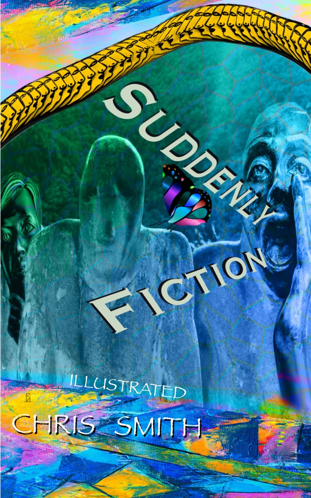

# SUDDENLY FICTION

## CLEE SMITH

[figure not shown]

Copyright © 2022 by Chris Smith

First Edition

All rights reserved.

No part of this publication may be reproduced, stored in or introduced into a retrieval system, or transmitted, in any form or by any means (electronic, mechanical, photocopying, recording, or otherwise), without the prior written permission of both the copyright owner and the publisher of this book.

Cover design by [Slip the Trap](https://www.slipthetrap.com)

Incidents, names, characters, and places are products of the author's imagination and used fictitiously. Resemblances to actual locales or events or persons living or dead, is entirely coincidental.

# CONTENTS

Preface

Chapter 1

Chapter 2

Chapter 3

Chapter 4

Chapter 5

Chapter 6

Chapter 7

Chapter 8

Chapter 9

Chapter 10

Chapter 11

Chapter 12

Chapter 13

Chapter 14

Chapter 15

Chapter 16

Chapter 17

Chapter 18

Chapter 19

Chapter 20

About the Author

[figure not shown]

**Fiction writing every day for 28 days.**

Originally my first attempt at writing fiction was based on an offer from an established author.

Lucky me, right?

Here's a portion of her offer via email:

> *"How about this. You write a story every day for one month. A challenge. Time limited every day. Only write for one hour, or a half hour. That's it. Whatever it is, it is. Stream of consciousness is more than acceptable.*

> *So what do you write about? Anything!*

> *Thirty minutes up. Now I can have a nice cup of coffee and go on with my day.*

> *I'm a writer who writes."*

> LINDA A. LAVID

For personal reasons, some of the 28 days of writing have been removed. Enjoy!

# CHAPTER 1

[figure not shown]

## Standing with my back against shelves of books I have never read and never will, I start to speak.

The tiny crowd coughs and adjusts while trying to get comfortable in those metal folding chairs.

Over eager eyes stare back, hanging on my every uttered syllable. As if I speak anywhere near as well as I write.

Writing takes time and only comes out of growth.

Speaking is in the now with no chance to edit. No do-overs.

I begin as usual with the giving of credit where credit is due. Always saying that my love Linda gifted me a wind up tomato shaped timer gadget which spawned a seemingly never ending series of books.

Each and every book a best seller, a light in the dark, life changing, songs were sung, wine and cheese served, yadda yadda yadda.

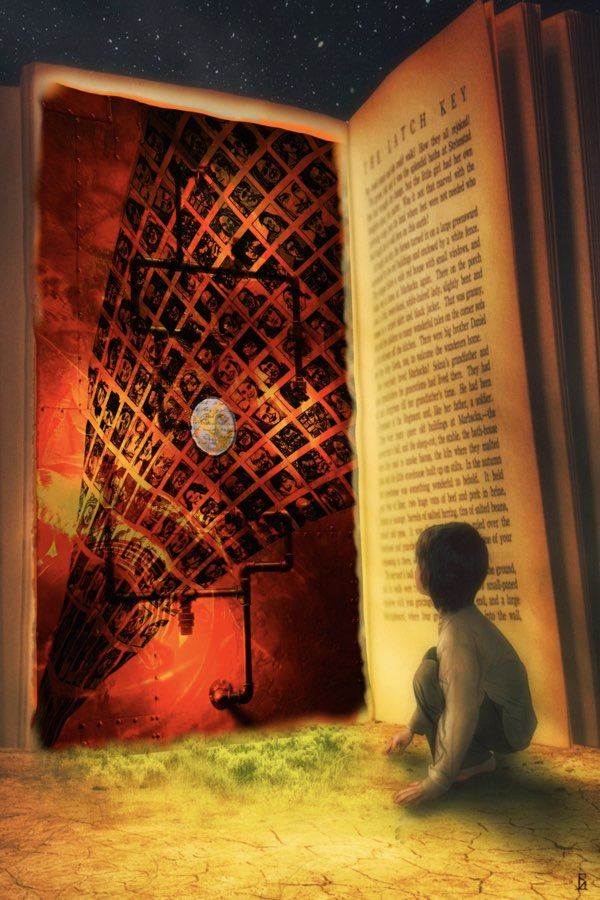

# CHAPTER 2

[figure not shown]

## There it sat on the carpeted floor, in total awe of the surroundings.

Only wearing a *fully loaded* cloth tightly fitted to its bottom, filling the room with that smell. It paused, pondering where to go next. A nearby cat struck a pose as if to say all of this was beneath them. Totally forgetting that once they had been a kitten.

Suddenly some unseen urge attracted *it*, a baby, to the only unprotected electrical outlet in the room. The race was on.

It began to crawl at break neck speed. Always amazing how fast we move when some unseen siren lures us into dangers. Having observed this pattern of behavior many times before, disaster was averted. Life often seems like a perpetual jar that is sometimes clear, sometimes cloudy, always and forever we look in or look out.

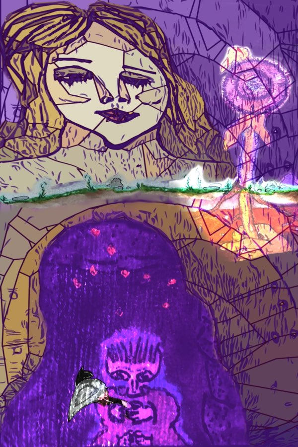

# CHAPTER 3

[figure not shown]

## Her email said "No! I do not like the word torpor!".

But I really do, it’s a cool word. Or at least I like the idea of going into a state of deep hibernation, a sleep without getting up to do anything, not even bodily functions like eating or pooping. Heck, hummingbirds do it, bees do it, and bears do it.

But all she wanted to talk about was why men no longer look at her the way they use to. It seems only a few years ago she complained about men looking at her like she was a side of beef. She insists on being way deeper than that, got it, she's deep. This despite most of her emails including a recently taken selfie. Always with a mirror in the background. Somehow. How many mirrors does she own? She always asks how she looks today, I say cute, but my heart is not in it.

Long ago we went steady, as they use to say, back in high school. In those days that meant hanging out together while working up the nerve to hold her hand. A bit like being a Puritan and a Victorian, all in one. Surely, even they had more fun.

She had literally tracked me down via my daughter, who directed her to my Facebook page. She "friended" me.

Is this how a stalk begins?

In time I "friended" her back, as I recognized her name and became certain it was the person I remembered. Then the emails came. An endless stream of thoughts ensued, her's not mine, as mine are way more than enough. Of course they were not deep at all but only her most mundane daily thoughts.

Time passed, years actually, with lots of emails exchanged. One day she slipped up and mentioned the hubby. Sure one can have married friends, but my question was is he aware and ok with our bordering on the intimate chitchats.

After a few quiet days, her response was that the hubby did not like this at all. So I "unfriended" her on Facebook. She went ballistic and sad, both at the same time. Her final email ended with the phrase "the dew has fallen from the lily" ... as it always does.

Our relationship entered torpor.

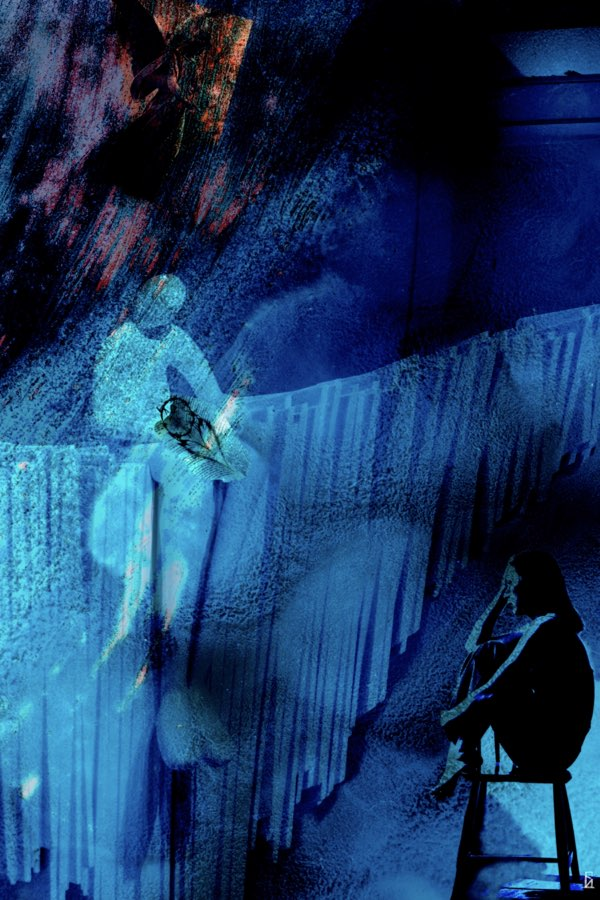

# CHAPTER 4

[figure not shown]

## Gina was a vampyre.

She stated this on our first date.

She stressed that she was not like the overly commercial Hollywood vampires, like in Buffy and movies.

Those were ridiculous.

She was the real deal, and wanted not just my blood but my soul.

Great, yet another Italian women in my life, I'm either blessed or cursed, not sure which. Plus I really only had myself, fun, and love to offer, and definitely not my soul.

Her was response was that's fine, we'll get to the *other* in time.

Our first date was at the airport. We worked at the same book store and she had asked me out. Despite her being much younger, yet always wearing long black Victorian dresses, I said yes. She was pretty with dark green eyes and long black hair and always serious, never a smile. By airport I mean we laid beside each other on the hood of my car at the end of a busy runway. We drank mead that she made herself while we watched airplanes takeoff. She loved evenings and that twilight time of day. We laid there making up stories about where the passengers were going. We talked for hours about traveling, likes and dislikes, pretty much first date stuff, except for the bits about vampyres. As first dates go, it was unique but nice. As evening became night then early morning, she suggested going to the *Au Pied De Cochon* for French onion soup. I had been to the *foot of the pig* many times before for late night or early morning soup. Those hot crocks of soup with cheese melted over the top were famous, as well as the myths about KGB spies defecting through their restroom windows. Afterwards we went to her apartment.

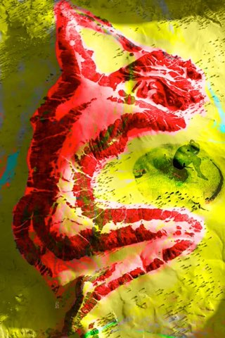

After our earlier talks, especially the vampyre bits, I expected her home to be dark with a touch of the sinister. It was that and more. There were lots of black candles, lots of melted wax, lots of stone gargoyles, lots of human skulls (they looked real), and red or black velour everywhere. It was a basement apartment with no windows so no way sunlight could ever enter, and no electric lights, just candle light. There was a huge canvas oil painting on a wall depicting some Maasai piercing, draining, and drinking fresh blood from a cow. As well as other gory artworks. There was that old musty basement smell too. On a book case mostly filled with very old untitled journals was two altered human skulls. They had been carved to fit a deck of cards in each skull, with a deck replacing the lower jaw in one, while another deck fit an opening above the eyes in the other. I think they were tarot decks but I'm not sure as she said I should never touch them. Of course the inevitable happens, blame on the mead, the pretty, or the unusual surroundings, but romance transcends all.

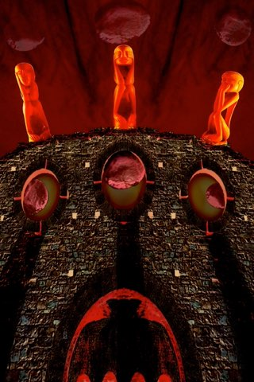

Time passed in pretty much same way as always until one evening she locked on to the topic of drinking my blood and reaping my soul. I was not keen on losing either one. She became a pit bull and just would not let it go. Of course, by this point in time I was kind of sort of in love with her. So I let her talk me through how, if I allowed it, this whole scenario would play out. The blood part sounded, well, bloody and painful, for me. The soul part, she said, was automatic after she drank a glass filled with my blood. To ease me into blood part of this, she offered to take a small amount from my right wrist. Not so bad, I thought, as I had given blood to the Red Cross and they take a pint. I said ok. At this she came close to smiling. And so the end began.

I had wondered about the necklace she always wore but never asked. Turns out it was a small dagger of a sort. A bit like an upside down ankh shape, but curved and made of bone or antler, with the loop being the handle. She pulled down and withdrew the blade. She sterilized it then poked it into my wrist. It was quick and painless really.

[figure not shown]

The things we do for love. Blood streamed out and into the palm of my hand. She pressed her face into my palm, lapping and slurping up my blood, moving slowly ever upward to the opening she had made in my wrist. Her lips wrapped around that tiny opening and she sucked hard and harder and harder. I pulled away. She cocked her head back and smiled as blood ran down her chin.

That was her first and only smile and an end to our relationship. I have never seen her since that evening. Gina was indeed a vampyre.

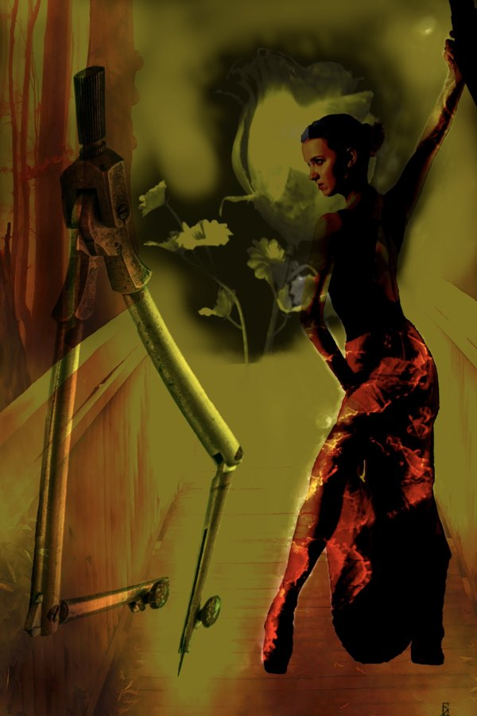

# CHAPTER 5

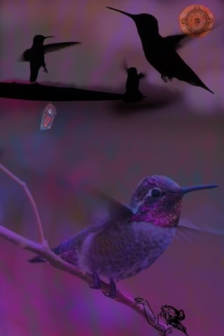

## A Blue Jay lay belly up on the ground.

Writhing and making gurgling sounds. Blood spurted from an eye creating a hallo of red around its head.

My first kill.

It was a lucky shot from over 30 yards away, and hit the bird in the head. A simple lead pellet fired from a pump action BB gun is all it took. Proudly I strutted over to see. For a brief moment I felt more adult than boy, manly even.

Squatting down over the bird and watching it slowly die, I felt a sudden flood of emotions and sick to my stomach. Any sense of luck or pride quickly vanished. I was filled with regret and a knowing that what just happened could never be undone, not ever. This bird was not killed for food, as we often did with chickens and pigs on the farm. Life on a farm often seemed full of meanness on purpose, which I never liked being a part of. My first kill had a nonchalant meanness about it, boyish. I cried. Promising myself to never repeat such a thing. My first kill haunts me to this day, reliving it anytime I see a bird sitting on a limb off in the distance.

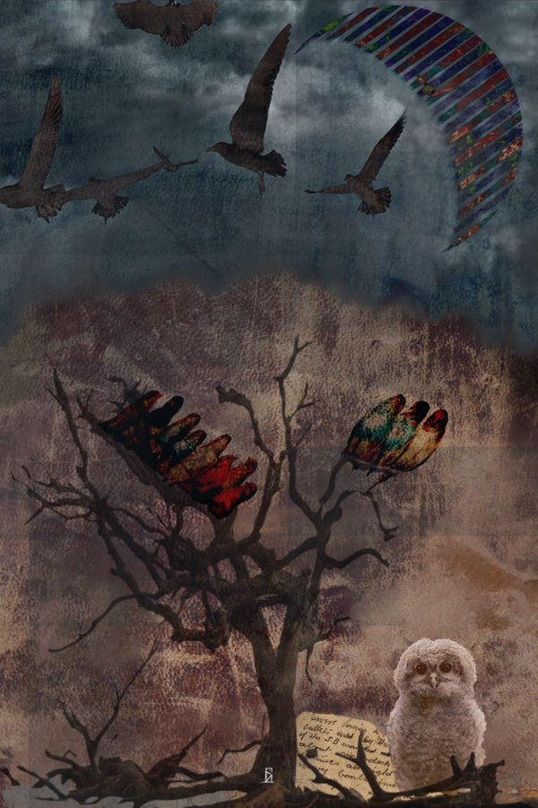

# CHAPTER 6

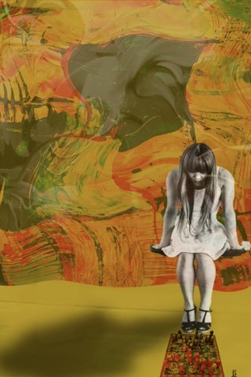

## Plum sat at her desk for exactly eight hours every work day for almost forty years.

An hour commute in to her work cubicle and an hour to get back home. Plum was a nickname, origin unknown, her real name was Edna Plummley.

She transcribed audio recordings of meetings onto paper using an electric typewriter. It was fast and so was she. Her grammar and spelling was the envy of coworkers. Whereas they relied on a book by Webster, kept beside their typewriters, she did not. Her Webster's remained in a desk drawer for many years now. A source of pride. She was an avid reader and collector of words. She was about to retire and wondered how to fill those empty ten hours per day soon to come. She hoped her nightly obsession would not take over her whole day.

Plum could not remember how or when this obsession had started. Perhaps after her first and only husband ran off with another man. So many years of being alone had turned her into a spinster. Could all of that loneliness have conjured this fixation of hers?

[figure not shown]

Initially she tried to write about that recurring scene in her diary:

*Doc said I should avoid all avid Diva's. The cod they serve is acid to the soul.*

*Do not fall into their void. Theirs is a false light offering no aid during strange times.*

*Just say "Ciao!" and walk away.*

But not only did such writing not capture the scene from her mind, the words just did not make any sense. She turned to art.

Trying to depict that scene using pencil/pen/ink line drawings, watercolors, oils, and most recently acrylic paintings. She even returned to the site to take photographs to use as reference for her art. Her home became filled with the exact same image from every angle and in every style imaginable. It had definitely been captured with hundreds of renderings scattered all about her home. She could stop herself from repeating the process over and over again.

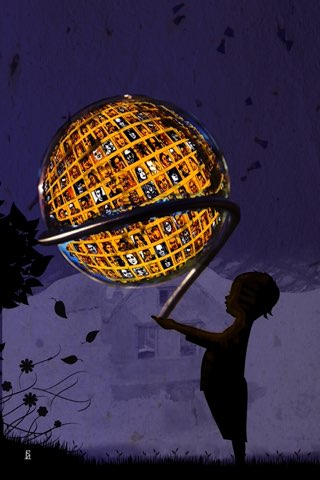

The scene was from Plum's childhood. As a young girl she had lived with an uncle for a few years. Why, she did not remember. There was something spellbinding about that scene, even though it was only made up of simple things: a shed, a rock, and the path leading there. She clearly recalls sitting on that smooth flat rock near the entrance to the shed. For hours and hours, as if time had stopped. In time she began to wonder if there was more to this obsession.

Something had been forgotten or buried deep down inside her. It lacked context, like a phantom on the periphery of understanding.

An unseen attractor beckoned her onward.

[figure not shown]

# CHAPTER 7

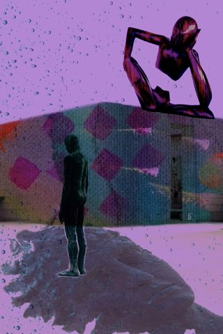

## Others often remarked that he lead a charmed life.

They said he was blessed to be so talented. Blessed not to have to grind out a living at some mundane job. He did not agree. His so called talent was a direct result of application, practice, and will power. Nothing more. He could not remember a time when he did not play a guitar of some sort. His first guitar was one his mother had learned on, but she had given up playing to raise a family. The guitar and lessons were a special gift from her. She told him he had an ear for music.

This lead to music school and a long list of bands, touring, and writing his own private songs. A life filled with booze, women, and song. Often all at the same time. Women were his muse, so many of them he said were just "a bit of all right". A refrain he repeated in many of his songs. He knew that those words were probably by Bob Dylan, as so many lyrics are. No relationship ever lasted more than a few months at best. He had an uncontrollable temper. It was even worse after a long night of drinking and performing. Muses paid for getting too close. Jail time seemed to deepen his music and appeal to women.

Over the years, a few times, he caught a glimpse of a repeated pattern in his life. Only to smother it in more song, booze, and women.

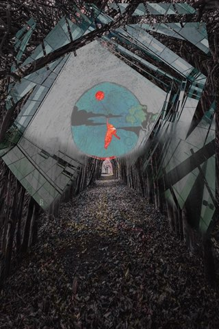

Unable to cope with looking directly at it. Years passed. Age happened. Nowadays he covered the songs of other artists during performances, at weddings and bars. Women had all but disappeared, especially the younger ones. There was a growing sense of realizing that a rut had built up around his life. He wondered if this was regret or just a feeling of being trapped in the blue hour. His latest song "The Dark Night of the Soul" seemed to be writing itself, but probably already done by Dylan as well.

# CHAPTER 8

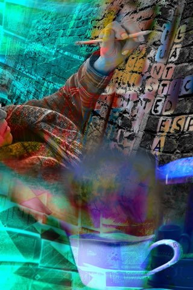

## Mia lived on the edge of a very small town.

A short walk away was a grocery store and the public library. She never learned to drive so did not own a car, and had no desire to travel. She had grown up and still lived in a house she inherited from her aunt. Whom she had called mother. Mother passed away just after she graduated from high school. There was no other family that she knew of. And she never knew how or why her aunt had raised her. Mia was the only person at her aunt's funeral. Her only semblance of a social life was limited to very brief interactions at the store or the library. She had never been on a date, no lovers, no children, no boyfriends or girlfriends.

Mother had hoarded candles and books of crossword puzzles. Thousands of them, maybe more. They were everywhere. Mother could never bear to solve those puzzles, entrapping words in those tiny boxes felt wrong to her. So all of the puzzles remained empty, left bare for Mia to fill in. After electricity was installed in the house, mother could not bear to burn the candles anymore either. Mia spent much of her time filling in the crossword puzzles. In the evening she preferred the warm glow of candlelight while mulling over a puzzle.

Mother's pride and joy had been a hard bound set of Oxford dictionaries that included a magnifying glass to read the tiny print on the thin rice paper pages. Mother never touched them and forbade Mia as well. Now, Mia used them every day, to collect words in journals, which helped with the puzzles. The only books she owned was Catcher in the Rye, A Clockwork Orange, and Practical Magic. It was probably the cover art on these books that had caught her eye, but she was never sure why she bought only those three. She didn't even like them, preferring the used library books.

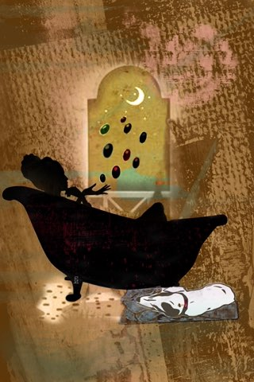

Sometimes on her short daily walks to the store and library, she would catch herself reflecting on her life versus the characters she read about in books. Do people really do all of those things? Is she odd, weird, or eccentric? Always returning to her daydreaming about today's crossword puzzle and what was that long word at 15 across. Once she even pondered about her name backwards, Mia is aim. She liked that, aim, to zero in on just the correct word to scribble it's letters into those tiny boxes. Her life felt full. Habitual and repetitive, sure. Occasionally she did wonder if living vicariously through words and stories was enough.

# CHAPTER 9

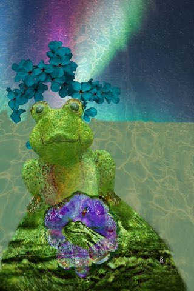

## There I was neck deep in pond water.

I seemed myself but different somehow. More instinctual. I burped, a lot, or something like burping. My life had changed the moment I met her. She had called me to mend a fence and install a new faucet. I did handyman work for a living. Not much of a living, but enough for rent, beer, chips, and cable TV. What else is there? Oh yeah, sex, of course. Enter Kass. Kass, aka Kassanova, was a tall lean yet shapely young woman with flaming red hair and bright green eyes. She was drop dead gorgeous. And she was looking for a lot more handy work than just a fence and faucet. This she made very clear from the get go. So after fixing the fence and faucet, I gave it my best at fixing her too. A dream come true except she was insatiable. And a bit into everything. Things I didn't know existed. Things I did not like. She would coax me on by saying my name all sexy like. “Again, Paris of Troy, again!” Yes, my first and middle names were Paris and Troy. Mom was a big fan of Greek myths, especially the one with Helen of Sparta and Paris of Troy and Aphrodite. You know, that crowd. Thanks mom. After several rounds between the bed posts, Kass declared that I belonged to her. Forever. I disagreed. Biggest mistake of my life.

[figure not shown]

I had noticed between bouts of sex, that her home contained some unusual things. Lots of sparkly colorful crystals, even more candles, and shelves of old leather bound books. Her kitchen was filled with vials and bottles of this and that. She called them potions and tinctures, I think. But I failed to put two and two together. Suddenly one evening, she announced that she was a witch, and that I would do what she wanted or else. Now she looked much older, a lot less attractive. Kind of serious. So I was ready to leave. Yet I froze in my tracks, unable to move. Her voice got a lot deeper uttering strange words and growl like noises. I didn't understand. The room got darker and candles burst to light forming a circle around me. She danced and pranced around the edge of the circle growling and speaking gibberish. I was trapped. After a while she entered the circle and kissed me on the lips. When she backed away, she seemed much taller. A giant. Everything got blurry.

So that was how I came to be in this pond. Very intent on catching a bug with only my tongue. I could feel Kass coming to check on me, her steps sounded like thunder making ripples in the water I sat in. She bent over and in a booming voice said "How's Paris, my little froggy, today?"

# CHAPTER 10

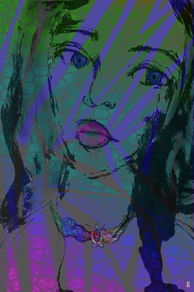

## I often said to Liz, "Hey, sweetness and light, how's tricks?".

She glowed a tiny blush. Every time. Something about those freckles just below her eyes combined with her blond hair and dark eyes hit a spot for me. Her voice too. This was desire, lust, and love, all packaged in a twenty something woman. But I was almost twenty years older. So my feelings felt odd, misplaced, disconnected. Not to mention that she was very well read, an intellectual. A master's degree in English Literature, she said. Her a talker. I was physical, movement, not all up in my head. I had a BS degree in Computer Science and not a dreamer. We were opposites in many ways.

We became acquainted while working part-time at a bookstore. I managed the store. She purchased the books. So we interacted often. A relationship, of sorts, grew. I became concerned about her walking alone to her apartment after work. The store closed at 1AM everyday, which seemed a dangerous thing for her to do alone. So I walked her home most nights. There was a comfort in her voice on those long, often intentionally roundabout, walks. I rarely understood much of what she was *on about,* politics or history or whatever, but I enjoyed her voice and being with her. Occasionally we did kiss. Those kind of kisses where the world and time itself seems to fall away. For a brainiac, she was a great kisser. She never once invited me inside. This state of affairs laster for many months.

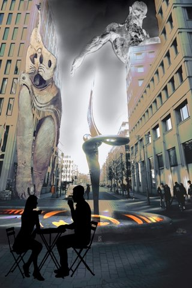

One evening we went for dinner at a nice outdoor restaurant. We agreed that there would be no talk of the bookstore, no gossip, and no alcohol. I sensed what she was about to say but did not cut her off at the pass. Let her say it, her way, in that moment. She did, slowly, gently. For once, not so intellectual, but emotional. She struggled with the words, a rarity for her. Essentially she did not want to fall in love, with me or anyone. She thought she felt love creeping up. She was not ready for *'till death do us part* and all that jazz. I let her talk it out. Only listening, nodding, and probably betraying my inner feelings somehow.

After that dinner we worked together for two more years. I continued to walk her home, sometimes. She talked. I listened, the same as many nights before. We did not hold hands nor kiss, ever again. Neither did we speak of our other relationships. Some of whatever there was before no longer remained. It had fallen away.

# CHAPTER 11

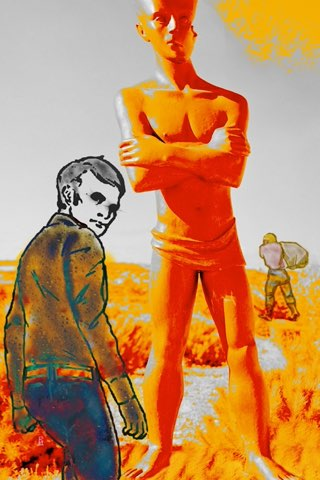

## As he rocked in his chair on the porch, Spurgeon found his thoughts drifting back to his childhood.

A time best forgotten. He thought all that strangeness had been forgotten long ago. But all of it had returned, like ocean tides, in and out of memory. Now a daily assault of what's, why's, and for's appeared in his afternoon catnaps.

The strangeness of youth mostly centered around his mother. His father was just a mean person that was mostly absent. As he was a traveling salesman prone to temper and violence when he was at home, which was rare. His father was unpleasant but easy to understand, keep quiet and stay out of his way. On the other hand, mother was always home. Looking like she just got out of bed. Always stumbling about wrapped in layers of silk. He pictured her now like one of those tipsy women in those 1940’s black and white movies. Always dolled up for romance with a glass of gin and tonic in hand. She was all that and far worst.

[figure not shown]

His mother was drunk most of the time, which wasn't so bad as she was at least a happy touchy drunk. But a very manipulative one. He remembered the photos taped on the outside and inside of the refrigerator, reminding him to eat all his food. Those pictures were enough to put you off food forever. Often placed just in front of his plate of food, there was a framed photo of a starving child in a far away land. Always the child was about his age it seemed. As if to say "That kid would eat all his food, why won't you?". When upset about whatever, mostly suspicious of dad's whereabouts, she would lock Spurgeon in the basement. The basement was dark and empty with puddles of water that had seeped from the walls. It smelled bad. There was nothing down there that could do any real harm, just a boy's imaginings, yet it made him cry every time. He recalled huddling near the locked door and poking fingers under it and out into the light. Hoping. Sometimes she would step on his fingers with her bedroom slippers. Painful, yet it was oddly comforting all the same. The food and various punishments continued for many years.

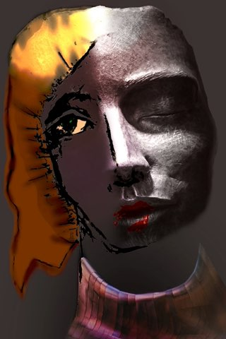

During his high school years, mother's manipulation changed to the bizarre. Often she would sit on the floor, so he did as well, as she observed and communicated with the frolicking tiny pink elephants she saw encircling us. Not once did he see anything. He thought she was faking all this strangeness, for pity's sake, to keep him forever bound in her world. This escalated into contrived late night hysteria and panic attacks by her. After dark sometimes there would be loud knocks at the front door. Running to see, there would be mother crying with a handwritten note in her hands. She said no one was there just the note she held. She looked scared. The note said that she must divorce father immediately. Or someone named Olly was going to shoot and kill both mother and him. She showed me the note. The handwriting looked like mother's. Each time this happened mother somehow managed to whip the event up into a frenzy of panicked activity. He remembered the feeling of being afraid and being swept along with mother. This always ended with driving around in the car and eventually stopping at a fast food restaurant. Having milkshakes and french fries. Just to calm down then returning home.

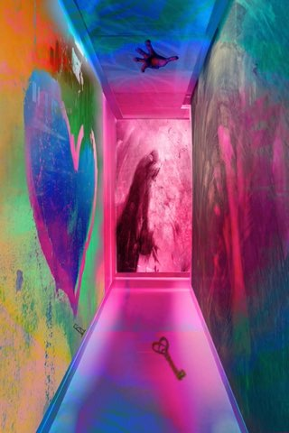

Spurgeon did leave home after high school and never saw his father or mother ever again. Childhood had been survived and that strangeness had passed. Until one day he had received a birthday card in the mail. The envelope did not have a return address. Inside there was a card with a picture of a pink elephant floating in the air holding a blue balloon.

It read "Happy Birthday son, Love Dad & Olly". That handwriting looked familiar.

Back came a flood of memories best never revisited.